# Declining Fertility Rates & Effects on GDP

Collaborators: John Iglesias

# Introduction

The purpose of this project is to walk through a data science pipeline while exploring the world's fertility rate trends and its relationship with global GDP (gross domestic output). Several countries around the globe have experienced decreasing fertility rates for the past few decades which has raised some ears for Japan, Germany, Italy, and many others. These governments are concerned about the potential economic consequences, including a shrinking workforce, increased strain on social welfare systems, and reduced GDP.

Let's take a look ourselves by diving into the past 50 years of data on the world's GDP and birth rates and see if the world's policymakers should take immediate action. We will be using data provided by the world bank API: https://data.worldbank.org/indicator/SP.DYN.CBRT.IN

# Data Processing

```python
import requests
import pandas as pd
import matplotlib.pyplot as plt
import pycountry
import plotly.express as px
import plotly.graph_objs as go
import plotly.offline as pyo
import json
import re
import seaborn as sns






pd.set_option("display.max_rows", 20000)
```

Lets make a functions which retrieves all region names according to the world bank. These are the regions which we will cover in our pipeline.

```python
def getAllRegions():
    '''returns mapping of region to region id according to world bank'''
    url = f"http://api.worldbank.org/v2/country/"
    params = {
        "format": "json",
        "date": "1970:2020",
    }
    response = requests.get(url, params=params)
    response_json = response.json()
    regions = {}
    regionsRaw = response_json[1]

    for entry in regionsRaw:
        id = entry['region']['id']
        name = entry['region']['value']
        regions[name] = id
    del regions['Aggregates'] #remove aggregates
    return regions
allRegions = getAllRegions()
allRegions
```

```
{'Latin America & Caribbean ': 'LCN',
 'South Asia': 'SAS',
 'Sub-Saharan Africa ': 'SSF',
 'Europe & Central Asia': 'ECS',
 'Middle East & North Africa': 'MEA',
 'East Asia & Pacific': 'EAS',
 'North America': 'NAC'}
```

We need a helper function to extract the region date and birth rate values from html strings which we http request from the world bank API. An HTTP request is a message sent by a client (web browser or an application) to a server, using the Hypertext Transfer Protocol (HTTP). This is standard procedure for data communication between a server and client.

Read more about http requests: https://www.w3schools.com/python/module_requests.asp

```python
def parseRegionRow(rawStr):
    '''given an html string, parses string for year,
    and birth rate value, returns tuple'''
    # Extract date
    start = rawStr.find("<wb:date>") + len("<wb:date>")
    end = rawStr.find("</wb:date>", start)
    date = rawStr[start:end].strip()

    # Extract value
    value_pattern = r'<wb:value>(.*?)</wb:value>'
    match = re.search(value_pattern, rawStr)
    value = None
    if match:
        value = float(match.group(1))

    return(date, value)
```

Now let's query the API for region birth rates since 1970. The API call returns an html string of the data pertinent to the provided regionID. For each piece of data returned from the request, lets call our parse function to extract the year and birth rate for the region.

```python
def parseRegionData(regionID):
    '''retrieves raw string html data for region's birth rate data
    since 1970, returns list of tuples for each year and birth rate'''
    url = f'http://api.worldbank.org/v2/country/{regionID}/indicator/SP.DYN.CBRT.IN?per_page=10000&date=1970:2022'

    # Send an HTTP GET request to the API endpoint
    response = requests.get(url)

    # Extract data from the response
    dataRaw = response.content.decode('utf-8').split('\n')

    #data is in html string format
    rawRegionData = ', '.join(dataRaw)
    rawRegionData = rawRegionData.split("<wb:data>\r,")

    output = []
    for s in rawRegionData:
        output.append(parseRegionRow(s))
    output = output[1:]
    return output
```

Let's make a function which queries the API for each region, parses the data, and inserts it into a pandas dataframe. Let's call this dataframe regionBirthRateDF

Read more about pandas library: https://pandas.pydata.org/docs/reference/api/pandas.DataFrame.html

```python
def getRegionBirthRateDF():
    '''returns df for birth rates for each world region from 1970-2022'''
    allDFs = [] #contains each df for each region
    for region in allRegions:
        data = parseRegionData(allRegions[region])
        regionDF = pd.DataFrame([(tup[0], tup[1]) for tup in data], columns=['year', 'birth_rate'])
        #add country column
        regionDF.insert(0, 'region', region)
        allDFs.append(regionDF)
    #combine all dfs
    allDFs = pd.concat(allDFs, ignore_index=True)
    return allDFs

regionBirthRateDF = getRegionBirthRateDF()
regionBirthRateDF.head(10)
```

|  | region | year | birth_rate |
| --- | --- | --- | --- |
| 0 | Latin America & Caribbean | 2022 | NaN |
| 1 | Latin America & Caribbean | 2021 | 14.778653 |
| 2 | Latin America & Caribbean | 2020 | 15.100340 |
| 3 | Latin America & Caribbean | 2019 | 15.503753 |
| 4 | Latin America & Caribbean | 2018 | 15.995688 |
| 5 | Latin America & Caribbean | 2017 | 16.306909 |
| 6 | Latin America & Caribbean | 2016 | 16.549259 |
| 7 | Latin America & Caribbean | 2015 | 17.053800 |
| 8 | Latin America & Caribbean | 2014 | 17.331315 |
| 9 | Latin America & Caribbean | 2013 | 17.558559 |

Now let's compile a dataframe for every country instead of the regions

```python
def getCountryBirthRateDF() -> pd.DataFrame:
    ''''returns df of every country's birth rate annually since 1970'''
    # Get a list of all country codes
    url = "http://api.worldbank.org/v2/country/all?per_page=500&format=json"
    response = requests.get(url)
    country_codes = [c['id'] for c in response.json()[1]]

    # Retrieve birth rate data for each country
    data = []
    for country_code in country_codes:
        url = f"http://api.worldbank.org/v2/country/{country_code}/indicator/SP.DYN.CBRT.IN"
        params = {
            "format": "json",
            "date": "1970:2020",
        }
        response = requests.get(url, params=params)
        response_json = response.json()
        # Check if the response is valid before iterating over it
        if len(response_json) > 1:
            if response_json[1]:
                for entry in response_json[1]:
                    data.append({
                        "country": entry["country"]["value"],
                        "date": entry["date"],
                        "birth_rate": entry["value"],
                    })

    # Convert the data to a pandas DataFrame
    df = pd.DataFrame(data)
    return df
```

Let's name it birthCountryDF

```python
birthCountryDF = getCountryBirthRateDF()
```

```python
birthCountryDF.head(10)
```

|  | country | date | birth_rate |
| --- | --- | --- | --- |
| 0 | Aruba | 2020 | 8.102 |
| 1 | Aruba | 2019 | 9.138 |
| 2 | Aruba | 2018 | 9.881 |
| 3 | Aruba | 2017 | 11.530 |
| 4 | Aruba | 2016 | 12.300 |
| 5 | Aruba | 2015 | 12.428 |
| 6 | Aruba | 2014 | 13.533 |
| 7 | Aruba | 2013 | 13.316 |
| 8 | Aruba | 2012 | 12.723 |
| 9 | Aruba | 2011 | 12.246 |

Let's make a helper function which given a place string, returns true if it is a country, or false otherwise.

```python
allCountries = set()
for country in pycountry.countries:
    allCountries.add(country.name.lower())

def isCountry(place):
    '''returns true if place is a country, false ow'''
    return place.lower() in allCountries
```

Let's remove rows from the birthCountryDF that are not countries, as the DF has many rows which include regions.

```python
#remove rows that're not countries
birthCountryDF = birthCountryDF[birthCountryDF['country'].apply(lambda x: isCountry(str(x)))]

#rename date column
birthCountryDF = birthCountryDF.rename(columns={'date': 'year'})

birthCountryDF.head(10)
```

|  | country | year | birth_rate |
| --- | --- | --- | --- |
| 0 | Aruba | 2020 | 8.102 |
| 1 | Aruba | 2019 | 9.138 |
| 2 | Aruba | 2018 | 9.881 |
| 3 | Aruba | 2017 | 11.530 |
| 4 | Aruba | 2016 | 12.300 |
| 5 | Aruba | 2015 | 12.428 |
| 6 | Aruba | 2014 | 13.533 |
| 7 | Aruba | 2013 | 13.316 |
| 8 | Aruba | 2012 | 12.723 |
| 9 | Aruba | 2011 | 12.246 |

Let's compile a dataframe of country GDPs and call it gdpCountryDF

```python
def get_gdp_df():
    '''returns df of every country's gdp annually since 1970'''
    url = 'https://api.worldbank.org/v2/country/all/indicator/NY.GDP.MKTP.CD?per_page=20000&date=1970:2022&format=json'
    response = requests.get(url)

    # Extract JSON data from response
    data = response.json()
    df = pd.json_normalize(data[1])

    # get relevant columns
    df = df[['country.value', 'date', 'value']]

    # Rename columns
    df.columns = ['country', 'year', 'gdp']


    return df

gdpCountryDF = get_gdp_df()
gdpCountryDF.head(10)
```

|  | country | year | gdp |
| --- | --- | --- | --- |
| 0 | Africa Eastern and Southern | 2022 | NaN |
| 1 | Africa Eastern and Southern | 2021 | 1.089454e+12 |
| 2 | Africa Eastern and Southern | 2020 | 9.341791e+11 |
| 3 | Africa Eastern and Southern | 2019 | 1.009052e+12 |
| 4 | Africa Eastern and Southern | 2018 | 1.016697e+12 |
| 5 | Africa Eastern and Southern | 2017 | 1.030482e+12 |
| 6 | Africa Eastern and Southern | 2016 | 8.898593e+11 |
| 7 | Africa Eastern and Southern | 2015 | 9.231439e+11 |
| 8 | Africa Eastern and Southern | 2014 | 1.003403e+12 |
| 9 | Africa Eastern and Southern | 2013 | 9.826771e+11 |

Lets extract the region and country data and make 2 new tables.

```python
#remove countrues so regions remain
gdpRegionDF = gdpCountryDF[gdpCountryDF['country'].apply(lambda x: not isCountry(str(x)))]
gdpRegionDF = gdpRegionDF.rename(columns={'country': 'region'})



#remove rows that're not countries
gdpCountryDF = gdpCountryDF[gdpCountryDF['country'].apply(lambda x: isCountry(str(x)))]
```

Let's check out every region in the gdpRegionDF

```python
'''check all regions'''
gdpRegionDF['region'].unique()
```

```
array(['Africa Eastern and Southern', 'Africa Western and Central',
       'Arab World', 'Caribbean small states',
       'Central Europe and the Baltics', 'Early-demographic dividend',
       'East Asia & Pacific',
       'East Asia & Pacific (excluding high income)',
       'East Asia & Pacific (IDA & IBRD countries)', 'Euro area',
       'Europe & Central Asia',
       'Europe & Central Asia (excluding high income)',
       'Europe & Central Asia (IDA & IBRD countries)', 'European Union',
       'Fragile and conflict affected situations',
       'Heavily indebted poor countries (HIPC)', 'High income',
       'IBRD only', 'IDA & IBRD total', 'IDA blend', 'IDA only',
       'IDA total', 'Late-demographic dividend',
       'Latin America & Caribbean',
       'Latin America & Caribbean (excluding high income)',
       'Latin America & the Caribbean (IDA & IBRD countries)',
       'Least developed countries: UN classification',
       'Low & middle income', 'Low income', 'Lower middle income',
       'Middle East & North Africa',
       'Middle East & North Africa (excluding high income)',
       'Middle East & North Africa (IDA & IBRD countries)',
       'Middle income', 'North America', 'Not classified', 'OECD members',
       'Other small states', 'Pacific island small states',
       'Post-demographic dividend', 'Pre-demographic dividend',
       'Small states', 'South Asia', 'South Asia (IDA & IBRD)',
       'Sub-Saharan Africa', 'Sub-Saharan Africa (excluding high income)',
       'Sub-Saharan Africa (IDA & IBRD countries)', 'Upper middle income',
       'World', 'Bahamas, The', 'Bolivia', 'British Virgin Islands',
       'Channel Islands', 'Congo, Dem. Rep.', 'Congo, Rep.',
       "Cote d'Ivoire", 'Curacao', 'Egypt, Arab Rep.', 'Gambia, The',
       'Hong Kong SAR, China', 'Iran, Islamic Rep.',
       "Korea, Dem. People's Rep.", 'Korea, Rep.', 'Kosovo',
       'Kyrgyz Republic', 'Lao PDR', 'Macao SAR, China',
       'Micronesia, Fed. Sts.', 'Moldova', 'Slovak Republic',
       'St. Kitts and Nevis', 'St. Lucia', 'St. Martin (French part)',
       'St. Vincent and the Grenadines', 'Tanzania', 'Turkiye',
       'Venezuela, RB', 'Vietnam', 'Virgin Islands (U.S.)',
       'West Bank and Gaza', 'Yemen, Rep.'], dtype=object)
```

Let's make a regionDF containing the annual birth rates and GDP for each year since 1970. We do this by left joining the regionBirthRateDF with the gdpRegionDf. A left join is a dataframe join operation that combines rows from two tables based on a related column value, while including all rows from the first table and matching rows from the right table. If a matching row doesn't exist in the right table, null values are used for the columns from the right table.

Pandas merge operations: https://pandas.pydata.org/docs/reference/api/pandas.DataFrame.merge.html

```python
'''left join regionBirthRateDf with regionGDP df'''

#convert year columns to int
regionBirthRateDF['year'] = regionBirthRateDF['year'].astype(int)
gdpRegionDF['year'] = gdpRegionDF['year'].astype(int)

#remove whitespace from region values
gdpRegionDF = gdpRegionDF.apply(lambda x: x.str.strip() if x.dtype == "object" else x)
regionBirthRateDF = regionBirthRateDF.apply(lambda x: x.str.strip() if x.dtype == "object" else x)

regionDF = regionBirthRateDF.merge(gdpRegionDF, on=['region', 'year'], how='left')
regionDF.head(10)
```

|  | region | year | birth_rate | gdp |
| --- | --- | --- | --- | --- |
| 0 | Latin America & Caribbean | 2022 | NaN | NaN |
| 1 | Latin America & Caribbean | 2021 | 14.778653 | 5.454429e+12 |
| 2 | Latin America & Caribbean | 2020 | 15.100340 | 4.742372e+12 |
| 3 | Latin America & Caribbean | 2019 | 15.503753 | 5.618711e+12 |
| 4 | Latin America & Caribbean | 2018 | 15.995688 | 5.702983e+12 |
| 5 | Latin America & Caribbean | 2017 | 16.306909 | 5.831864e+12 |
| 6 | Latin America & Caribbean | 2016 | 16.549259 | 5.249605e+12 |
| 7 | Latin America & Caribbean | 2015 | 17.053800 | 5.372086e+12 |
| 8 | Latin America & Caribbean | 2014 | 17.331315 | 6.428177e+12 |
| 9 | Latin America & Caribbean | 2013 | 17.558559 | 6.303809e+12 |

Lets do the same except for countries

```python
'''left join gdp and birth rate tables by gdp for countries'''

#remove whitespace from region values
gdpCountryDF = gdpCountryDF.apply(lambda x: x.str.strip() if x.dtype == "object" else x)
birthCountryDF = birthCountryDF.apply(lambda x: x.str.strip() if x.dtype == "object" else x)

countryDF = gdpCountryDF.merge(birthCountryDF, on=['country', 'year'], how='left')
countryDF.head(10)
```

|  | country | year | gdp | birth_rate |
| --- | --- | --- | --- | --- |
| 0 | Afghanistan | 2022 | NaN | NaN |
| 1 | Afghanistan | 2021 | 1.478686e+10 | NaN |
| 2 | Afghanistan | 2020 | 2.014344e+10 | 36.051 |
| 3 | Afghanistan | 2019 | 1.890449e+10 | 36.466 |
| 4 | Afghanistan | 2018 | 1.841885e+10 | 36.927 |
| 5 | Afghanistan | 2017 | 1.889635e+10 | 37.342 |
| 6 | Afghanistan | 2016 | 1.801956e+10 | 37.936 |
| 7 | Afghanistan | 2015 | 1.999816e+10 | 38.803 |
| 8 | Afghanistan | 2014 | 2.055058e+10 | 39.105 |
| 9 | Afghanistan | 2013 | 2.056449e+10 | 39.601 |

# Exploratory data analysis

Plot each country's GDP since 1970 using the matplotlib library.

Python matplotlib: https://matplotlib.org/

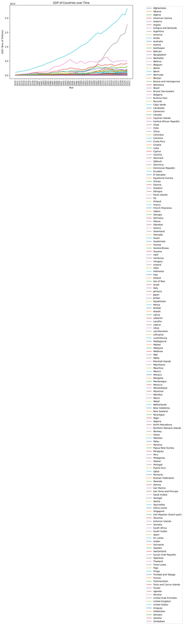

```python
fig, ax = plt.subplots(figsize=(10, 6))

for country in countryDF.country.unique():
    sub_df = countryDF[countryDF.country == country]
    ax.plot(sub_df.year, sub_df.gdp, label=country)

ax.set_xlabel('Year')
ax.set_ylabel('GDP (Tens of Trillions)')
ax.set_title('GDP of Countries over Time')
ax.legend(loc='upper left', bbox_to_anchor=(1.1, 1))
# rotate the x-ticks by 45 degrees
plt.xticks(rotation=90)
# flip the x-axis
ax.invert_xaxis()

plt.show()
```

Lets instead plot boxplots marking the GDPs for each year in order to get a better understanding of each year's GDP distribution. Boxplots visualize the median, quartiles, and outliers for a dataset.

Before plotting our boxplots for each year, let's get rid of the null column values with .dropna(). We also use .groupby() to group the data by each year.

Boxplots: https://www.simplypsychology.org/boxplots.html

Groupby: https://pandas.pydata.org/docs/reference/api/pandas.DataFrame.groupby.html

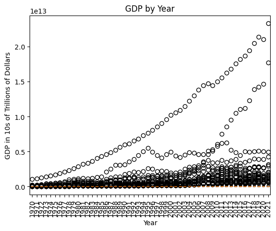

```python
# Filter out rows with missing GDP values
filtered_df = countryDF.dropna(subset=['gdp'])

# Group the data by year
grouped_df = filtered_df.groupby('year')

# Create a list to store the GDP values for each year
data = []

# Iterate over each year and append GDP values to the data list
for year, group in grouped_df:
    data.append(group['gdp'])

# Create a boxplot for each year
plt.boxplot(data)

# Set the x-axis labels to the year values and rotate them by 90 degrees
plt.xticks(range(1, len(grouped_df) + 1), [str(year) for year, _ in grouped_df], rotation=90)

# Add labels and title to the plot
plt.xlabel('Year')
plt.ylabel('GDP in 10s of Trillions of Dollars')
plt.title('GDP by Year')


# Show the plot
plt.show()
```

We can see that the majority of the world's GDP is increasing relatively slowly since 1970 as compared to the US and China. There are significant outliers for GDP each year, these outliers mostly track US and China GDP.

Let's visualize the birth rate's for each country annually with a scatterplot. A scatter plot displays individual data points as dots on a graph.

Scatterplot: https://www.khanacademy.org/math/statistics-probability/describing-relationships-quantitative-data/introduction-to-scatterplots/a/scatterplots-and-correlation-review#:~:text=What%20is%20a%20scatterplot%3F,values%20for%20the%20two%20variables.

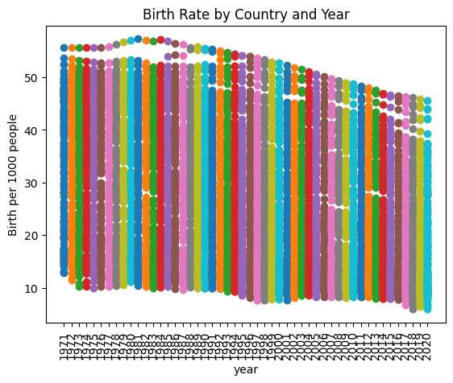

```python
# Filter out rows with missing birth_rate values
filtered_df = countryDF.dropna(subset=['birth_rate'])

# Group the data by year
grouped_df = filtered_df.groupby('year')

# Create a scatterplot for each year
for year, group in grouped_df:
    plt.scatter(group['year'], group['birth_rate'], label=str(year))

# Set the x-axis labels to rotate for better visibility
plt.xticks(rotation=90)

# Add labels and title to the plot
plt.xlabel('year')
plt.ylabel('Birth per 1000 people')
plt.title('Birth Rate by Country and Year')



# Show the plot
plt.show()
```

We notice a slight trend down year by year in terms of birth rate, let's try boxplots to better understand the distribution trends

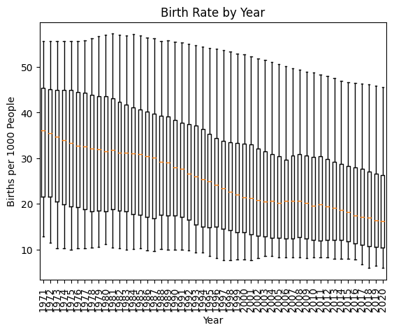

```python
# Filter out rows with missing birth_rate values
filtered_df = countryDF.dropna(subset=['birth_rate'])

# Group the data by year
grouped_df = filtered_df.groupby('year')

# Create a list to store the birth rate values for each year
data = []

# Iterate over each year and append birth rate values to the data list
for year, group in grouped_df:
    data.append(group['birth_rate'])

# Create a boxplot for each year
plt.boxplot(data)

# Set the x-axis labels to the year values
plt.xticks(range(1, len(grouped_df)+1), [str(year) for year, _ in grouped_df], rotation=90)

# Add labels and title to the plot
plt.xlabel('Year')
plt.ylabel('Births per 1000 People')
plt.title('Birth Rate by Year')

# Show the plot
plt.show()
```

Lets plot the GDP by region

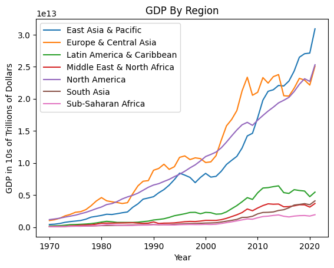

```python
# Filter the DataFrame to include data from 1970 onwards
filtered_df = regionDF[regionDF['year'] >= 1970]

# Group the data by region and iterate over each region
grouped_df = filtered_df.groupby('region')
for region, data in grouped_df:
    plt.plot(data['year'], data['gdp'], label=region)

# Set plot labels and title
plt.xlabel('Year')
plt.ylabel('GDP in 10s of Trillions of Dollars')
plt.title('GDP By Region')
plt.legend()

# Display the plot
plt.show()
```

We notice that there is a general trend upwards for GDP for all regions. However, regions East Asia & Pacific, Europe & Central Asia, and North America have had the highest spike.

Lets check region birth rates.

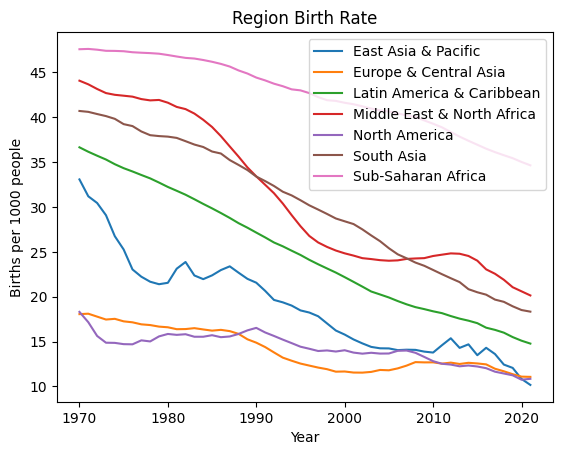

```python
# Filter the DataFrame to include data from 1970 onwards
filtered_df = regionDF[regionDF['year'] >= 1970]

# Group the data by region and iterate over each region
grouped_df = filtered_df.groupby('region')
for region, data in grouped_df:
    plt.plot(data['year'], data['birth_rate'], label=region)

# Set plot labels and title
plt.xlabel('Year')
plt.ylabel('Births per 1000 people')
plt.title('Region Birth Rate')
plt.legend()

# Display the plot
plt.show()
```

# Model: Analysis, Hypothesis Testing, Machine Learning

Lets confirm if there is a negative relationship for region birth rates using an OLS regression. Ordinary Least Squares regression models the relationship between a dependent variable and independent variable(s). A linear regression finds the best-fit line that minimizes the sum of squared residuals. Squared residuals are the variance away from the residual line that the real data points stray away from.

We will be using the statsmodels.api library to run the regression.

statsmodels.api: https://www.statsmodels.org/stable/index.html

OLS: https://www.xlstat.com/en/solutions/features/ordinary-least-squares-regression-ols

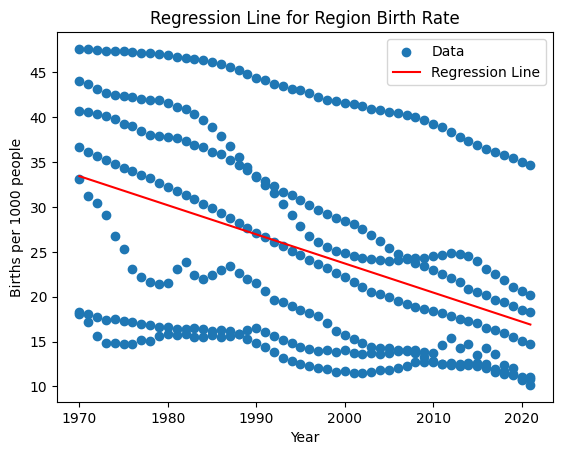

```python
import statsmodels.api as sm

# Filter the DataFrame to remove missing values
filtered_df = regionDF.dropna(subset=['birth_rate'])

# Add a constant column for the intercept term in the regression
filtered_df['intercept'] = 1

# Create the design matrix X and the target variable y
X = filtered_df[['intercept', 'year']]
y = filtered_df['birth_rate']

# Fit the linear regression model
model = sm.OLS(y, X)
results = model.fit()

# Get the predicted values from the regression model
predicted_values = results.predict(X)

# Plot the data points
plt.scatter(filtered_df['year'], filtered_df['birth_rate'], label='Data')

# Plot the regression line
plt.plot(filtered_df['year'], predicted_values, color='red', label='Regression Line')

# Set plot labels and title
plt.xlabel('Year')
plt.ylabel('Births per 1000 people')
plt.title('Regression Line for Region Birth Rate')
plt.legend()

# Display the plot
plt.show()
```

Lets print out the regression line's exact slope and y-intercept

```python
# Filter the DataFrame to remove missing values
filtered_df = regionDF.dropna(subset=['birth_rate'])

# Add a constant column for the intercept term in the regression
filtered_df['intercept'] = 1

# Create the design matrix X and the target variable y
X = filtered_df[['intercept', 'year']]
y = filtered_df['birth_rate']

# Fit the linear regression model
model = sm.OLS(y, X)
results = model.fit()

# Print the regression summary
print(results.summary())
```

```
                            OLS Regression Results
==============================================================================
Dep. Variable:             birth_rate   R-squared:                       0.193
Model:                            OLS   Adj. R-squared:                  0.190
Method:                 Least Squares   F-statistic:                     86.35
Date:                Thu, 11 May 2023   Prob (F-statistic):           1.44e-18
Time:                        12:38:08   Log-Likelihood:                -1353.1
No. Observations:                 364   AIC:                             2710.
Df Residuals:                     362   BIC:                             2718.
Df Model:                           1
Covariance Type:            nonrobust
==============================================================================
                 coef    std err          t      P>|t|      [0.025      0.975]
------------------------------------------------------------------------------
intercept    671.7454     69.583      9.654      0.000     534.907     808.583
year          -0.3240      0.035     -9.292      0.000      -0.393      -0.255
==============================================================================
Omnibus:                       42.614   Durbin-Watson:                   0.035
Prob(Omnibus):                  0.000   Jarque-Bera (JB):               18.299
Skew:                           0.344   Prob(JB):                     0.000106
Kurtosis:                       2.143   Cond. No.                     2.65e+05
==============================================================================

Notes:
[1] Standard Errors assume that the covariance matrix of the errors is correctly specified.
[2] The condition number is large, 2.65e+05. This might indicate that there are
strong multicollinearity or other numerical problems.
```

The regression coefficent has a slope of -0.3240 which is a significant negative slope for birth rates over time. The coefficient is statistically significant (P < 0.001), indicating that the relationship between year and birth_rate is unlikely to be due to chance.

Reading correlation coefficents: https://www.bmj.com/about-bmj/resources-readers/publications/statistics-square-one/11-correlation-and-regression

Lets run an OLS regression on the region GDPs

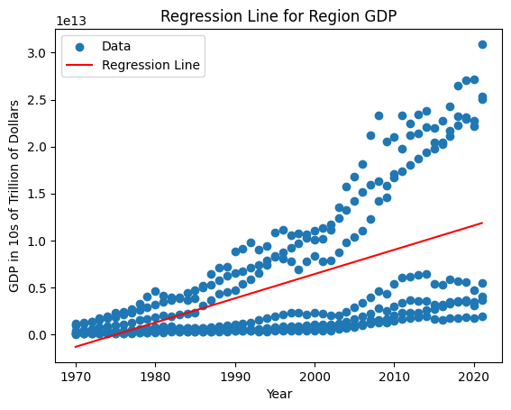

```python
# Filter the DataFrame to remove missing values
filtered_df = regionDF.dropna(subset=['gdp'])

# Add a constant column for the intercept term in the regression
filtered_df['intercept'] = 1

# Create the design matrix X and the target variable y
X = filtered_df[['intercept', 'year']]
y = filtered_df['gdp']

# Fit the linear regression model
model = sm.OLS(y, X)
results = model.fit()

# Get the predicted values from the regression model
predicted_values = results.predict(X)

# Plot the data points
plt.scatter(filtered_df['year'], filtered_df['gdp'], label='Data')

# Plot the regression line
plt.plot(filtered_df['year'], predicted_values, color='red', label='Regression Line')

# Set plot labels and title
plt.xlabel('Year')
plt.ylabel('GDP in 10s of Trillion of Dollars')
plt.title('Regression Line for Region GDP')
plt.legend()

# Display the plot
plt.show()
```

```python
# Filter the DataFrame to remove missing values
filtered_df = regionDF.dropna(subset=['gdp'])

# Add a constant column for the intercept term in the regression
filtered_df['intercept'] = 1

# Create the design matrix X and the target variable y
X = filtered_df[['intercept', 'year']]
y = filtered_df['gdp']

# Fit the linear regression model
model = sm.OLS(y, X)
results = model.fit()

# Print the regression summary
print(results.summary())
```

```
                            OLS Regression Results
==============================================================================
Dep. Variable:                    gdp   R-squared:                       0.313
Model:                            OLS   Adj. R-squared:                  0.312
Method:                 Least Squares   F-statistic:                     165.3
Date:                Thu, 11 May 2023   Prob (F-statistic):           2.04e-31
Time:                        12:38:09   Log-Likelihood:                -11210.
No. Observations:                 364   AIC:                         2.242e+04
Df Residuals:                     362   BIC:                         2.243e+04
Df Model:                           1
Covariance Type:            nonrobust
==============================================================================
                 coef    std err          t      P>|t|      [0.025      0.975]
------------------------------------------------------------------------------
intercept  -5.104e+14   4.01e+13    -12.724      0.000   -5.89e+14   -4.32e+14
year        2.584e+11   2.01e+10     12.856      0.000    2.19e+11    2.98e+11
==============================================================================
Omnibus:                       26.702   Durbin-Watson:                   0.088
Prob(Omnibus):                  0.000   Jarque-Bera (JB):               30.809
Skew:                           0.709   Prob(JB):                     2.04e-07
Kurtosis:                       3.146   Cond. No.                     2.65e+05
==============================================================================

Notes:
[1] Standard Errors assume that the covariance matrix of the errors is correctly specified.
[2] The condition number is large, 2.65e+05. This might indicate that there are
strong multicollinearity or other numerical problems.
```

The regression slope is is 2.584e+11. This means that for each one-unit increase in the year variable, the predicted value of the gdo variable increases by 2.584e+11. The coefficient is statistically significant (P < 0.001), indicating that the relationship between year and gdp is unlikely to be due to chance.

To test the relationship between region birth rate and GDP, we can use a statistical hypothesis test such as Pearson's correlation coefficient. The null hypothesis is that there is no relationship between birth rate and GDP for each region

Pearson's: https://www.scribbr.com/statistics/pearson-correlation-coefficient/#:~:text=The%20Pearson%20correlation%20coefficient%20(r,the%20relationship%20between%20two%20variables.&text=When%20one%20variable%20changes%2C%20the,changes%20in%20the%20same%20direction.

```python
import scipy.stats as stats

# Filter the DataFrame to remove missing values
filtered_df = regionDF.dropna(subset=['birth_rate', 'gdp'])

# Perform Pearson's correlation test
correlation, p_value = stats.pearsonr(filtered_df['birth_rate'], filtered_df['gdp'])

# Print the correlation coefficient and p-value
print("Correlation coefficient:", correlation)
print("p-value:", p_value)
```

```
Correlation coefficient: -0.6817742213241034
p-value: 4.429289249272849e-51
```

A hypothesis test is for making inferences about a population based on a sample of data; in this case drawing conclusions that GDP and birth rates have a relationship based on our data. Hypothesis testing involves formulating two competing hypotheses, the null hypothesis and the alternative hypothesis , and using statistical evidence to determine which hypothesis is more probable.

Hypothesis testing: https://www.statisticshowto.com/probability-and-statistics/hypothesis-testing/

What if we tried to find a correlation with each country as the data instead of region?

```python
# Filter the DataFrame to remove missing values
filtered_df = countryDF.dropna(subset=['birth_rate', 'gdp'])

# Perform Pearson's correlation test
correlation, p_value = stats.pearsonr(filtered_df['birth_rate'], filtered_df['gdp'])

# Print the correlation coefficient and p-value
print("Correlation coefficient:", correlation)
print("p-value:", p_value)
```

```
Correlation coefficient: -0.1984695429796589
p-value: 2.340956083955546e-69
```

# Interpretation: Insight & Policy Decision

Based on our observations throughout our analysis and modeling, we can safely say that:

1) The world's GDP by region has been steadily increasing over time and is likely to continue doing so in the future.

2) The world's birth rate by region has been steadily decreasing over time and is likely to continue doing so in the future

If we could conduct further research, we would visualize and spot the trends for GDP and birth rates for war-stricken countries, low income, middle income, and high income populations to see if there are any relationships for these groups.

To learn more about a given topic check the following links:¶

OLA Regression: https://towardsdatascience.com/simple-linear-regression-and-ols-introduction-to-the-theory-1b48f7c69867

String Parsing: https://towardsdatascience.com/strings-and-text-in-python-50be0452e0d3

Visualizing Data: https://matplotlib.org/

Processing Data w/Python: https://www.accel.ai/anthology/2022/3/24/data-processing-in-python#:~:text=Generally%20speaking%2C%20data%20processing%20consists,CSV%2C%20JSON%2C%20and%20HTML.

Read more about http requests: https://www.w3schools.com/python/module_requests.asp

Read more about pandas library: https://pandas.pydata.org/docs/reference/api/pandas.DataFrame.html

Pandas merge operations: https://pandas.pydata.org/docs/reference/api/pandas.DataFrame.merge.html

Python matplotlib: https://matplotlib.org/

Boxplots: https://www.simplypsychology.org/boxplots.html

Groupby: https://pandas.pydata.org/docs/reference/api/pandas.DataFrame.groupby.html

Scatterplot: https://www.khanacademy.org/math/statistics-probability/describing-relationships-quantitative-data/introduction-to-scatterplots/a/scatterplots-and-correlation-review#:~:text=What%20is%20a%20scatterplot%3F,values%20for%20the%20two%20variables.

Reading correlation coefficents: https://www.bmj.com/about-bmj/resources-readers/publications/statistics-square-one/11-correlation-and-regression

statsmodels.api: https://www.statsmodels.org/stable/index.html